# Data Table

Agosto, 2015

## Paquete data.table

- `data.table` permite manipular rápida y eficientemente datos almacenados en la `RAM`. Entre las operaciones más importantes tenemos:
  - Filtrado de datos.
  - Creación, modificación, eliminación de variables.
  - Operaciones Group by.
  - Resumir data
  - Joins

## Forma general

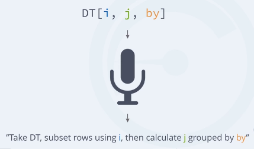

> `DT[i, j, by]`: Take DT, subset rows using `i`, calculate `j` grouped by `by`

## Forma general

- `data.table` funciona de manera similar que `SQL`:

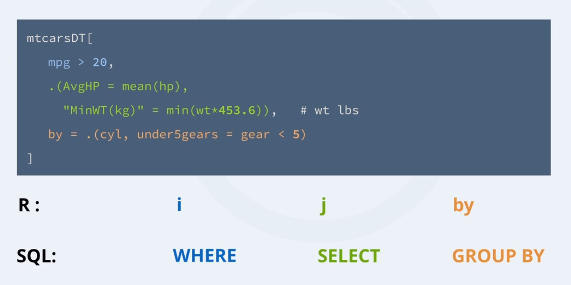

## Crear objetos data.table

- `data frame`

```r
DF <- data.frame(x=c("b","b","b","a","a"),y=rexp(5), z=rnorm(5))
DF
```

```
##   x          y          z
## 1 b 0.83398564 -2.1956630
## 2 b 0.06744229 -1.3012001
## 3 b 0.18485171 -0.5764621
## 4 a 0.57687859  1.3325446
## 5 a 1.38568620  0.8937860
```

- `data.table`

```r
DT <- data.table(x=c("b","b","b","a","a"),y=rexp(5), z=rnorm(5))
DT
```

```
##    x         y          z
## 1: b 1.7982199  0.7367163
## 2: b 3.0905041  0.2410225
## 3: b 1.1000852  0.9787489
## 4: a 0.8698684 -0.4532953
## 5: a 0.6871447  0.7445107
```

## data frame vs data.table

- `data frame`

```r
head(mtcars, n = 4)
```

```
##                 mpg cyl disp  hp drat    wt  qsec vs am gear carb
## Mazda RX4      21.0   6  160 110 3.90 2.620 16.46  0  1    4    4
## Mazda RX4 Wag  21.0   6  160 110 3.90 2.875 17.02  0  1    4    4
## Datsun 710     22.8   4  108  93 3.85 2.320 18.61  1  1    4    1
## Hornet 4 Drive 21.4   6  258 110 3.08 3.215 19.44  1  0    3    1
```

- `data.table`

```r
mtcarsDT <- data.table(mtcars)
head(mtcarsDT, n = 4)
```

```
##     mpg cyl disp  hp drat    wt  qsec vs am gear carb
## 1: 21.0   6  160 110 3.90 2.620 16.46  0  1    4    4
## 2: 21.0   6  160 110 3.90 2.875 17.02  0  1    4    4
## 3: 22.8   4  108  93 3.85 2.320 18.61  1  1    4    1
## 4: 21.4   6  258 110 3.08 3.215 19.44  1  0    3    1
```

## data frame vs data.table

- `data frame`

```r
class(mtcars)
```

```
## [1] "data.frame"
```

- `data.table`

```r
mtcarsDT <- data.table(mtcars)
class(mtcarsDT)
```

```
## [1] "data.table" "data.frame"
```

## Objetos data.table en área de trabajo

```r
tables()
```

```
##      NAME     NROW NCOL MB COLS
## [1,] DT          5    3  1 x,y,z
## [2,] mtcarsDT   32   11  1 mpg,cyl,disp,hp,drat,wt,qsec,vs,am,gear,carb
##      KEY
## [1,]
## [2,]
## Total: 2MB
```

```r
carsDT <- data.table(cars)
tables()
```

```
##      NAME     NROW NCOL MB COLS
## [1,] carsDT     50    2  1 speed,dist
## [2,] DT          5    3  1 x,y,z
## [3,] mtcarsDT   32   11  1 mpg,cyl,disp,hp,drat,wt,qsec,vs,am,gear,carb
##      KEY
## [1,]
## [2,]
## [3,]
## Total: 3MB
```

## data.table a data frame

- Un objeto `data.table` es a la vez un `data frame`, es decir podemos aplicar las funciones vistas anteriormente:

```r
DT
```

```
##    x         y          z
## 1: b 1.7982199  0.7367163
## 2: b 3.0905041  0.2410225
## 3: b 1.1000852  0.9787489
## 4: a 0.8698684 -0.4532953
## 5: a 0.6871447  0.7445107
```

```r
sapply(DT,class)
```

```
##           x           y           z
## "character"   "numeric"   "numeric"
```

## Subsetting

```r
DT <- data.table(x=rep(c("a","b","c"),each=3), y=c(1,3,6), v=1:9)
DT
```

```
##    x y v
## 1: a 1 1
## 2: a 3 2
## 3: a 6 3
## 4: b 1 4
## 5: b 3 5
## 6: b 6 6
## 7: c 1 7
## 8: c 3 8
## 9: c 6 9
```

```r
DT[2] # fila 2
```

```
##    x y v
## 1: a 3 2
```

## Subsetting

```r
DT[,v] # col v (como vector)
```

```
## [1] 1 2 3 4 5 6 7 8 9
```

```r
DT[,list(v)] # col v (como data.table)
```

```
##    v
## 1: 1
## 2: 2
## 3: 3
## 4: 4
## 5: 5
## 6: 6
## 7: 7
## 8: 8
## 9: 9
```

## Subsetting

```r
DT[,.(v)] # col v (como data.table)
```

```
##    v
## 1: 1
## 2: 2
## 3: 3
## 4: 4
## 5: 5
## 6: 6
## 7: 7
## 8: 8
## 9: 9
```

- En `data.table` `list()` es equivalente a `.()`

```r
DT[2:3,sum(v)] # sum(v) sobre filas 2, 3
```

```
## [1] 5
```

## Subsetting

```r
DT[c(FALSE,TRUE)] # filas (reciclado)
```

```
##    x y v
## 1: a 3 2
## 2: b 1 4
## 3: b 6 6
## 4: c 3 8
```

```r
DT[,2,] # col 2
```

```
## [1] 2
```

## Subsetting

```r
DT[, .(y),]
```

```
##    y
## 1: 1
## 2: 3
## 3: 6
## 4: 1
## 5: 3
## 6: 6
## 7: 1
## 8: 3
## 9: 6
```

## Subsetting

```r
DT[, 2, with = FALSE]
```

```
##    y
## 1: 1
## 2: 3
## 3: 6
## 4: 1
## 5: 3
## 6: 6
## 7: 1
## 8: 3
## 9: 6
```

## Subsetting

```r
colNum = 2
DT[, colNum, with = FALSE] # equivalente
```

```
##    y
## 1: 1
## 2: 3
## 3: 6
## 4: 1
## 5: 3
## 6: 6
## 7: 1
## 8: 3
## 9: 6
```

## Setkeys

```r
setkey(DT,x) # seteamos la col x como key
tables()
```

```
##      NAME     NROW NCOL MB COLS
## [1,] carsDT     50    2  1 speed,dist
## [2,] DT          9    3  1 x,y,v
## [3,] mtcarsDT   32   11  1 mpg,cyl,disp,hp,drat,wt,qsec,vs,am,gear,carb
##      KEY
## [1,]
## [2,] x
## [3,]
## Total: 3MB
```

## Subsetting

```r
DT["a"] # busqueda binaria (fast)
```

```
##    x y v
## 1: a 1 1
## 2: a 3 2
## 3: a 6 3
```

```r
DT[x=="a"] # equivalente
```

```
##    x y v
## 1: a 1 1
## 2: a 3 2
## 3: a 6 3
```

## Group by

```r
DT[,sum(v),by=x] # keyed by (agrupamos mediante la key)
```

```
##    x V1
## 1: a  6
## 2: b 15
## 3: c 24
```

```r
DT[,sum(v),by=key(DT)] # equivalente
```

```
##    x V1
## 1: a  6
## 2: b 15
## 3: c 24
```

```r
DT[,sum(v),by=y] # agrupamos por y
```

```
##    y V1
## 1: 1 12
## 2: 3 15
## 3: 6 18
```

## Group by

```r
DT["a",sum(v)] # sum(v) para 1 grupos
```

```
## [1] 6
```

```r
DT[c("a","b"),sum(v),by=.EACHI] # sum(v) para 2 grupos
```

```
##    x V1
## 1: a  6
## 2: b 15
```

## Joins

```r
X = data.table(c("b","c"),foo=c(4,2))
X
```

```
##    V1 foo
## 1:  b   4
## 2:  c   2
```

```r
DT[X] # join
```

```
##    x y v foo
## 1: b 1 4   4
## 2: b 3 5   4
## 3: b 6 6   4
## 4: c 1 7   2
## 5: c 3 8   2
## 6: c 6 9   2
```

## Joins

```r
DT[X, sum(v), by=.EACHI] # join y eval j para cada fila en i
```

```
##    x V1
## 1: b 15
## 2: c 24
```

```r
DT[X,mult="first"] # primera fila en cada grupo
```

```
##    x y v foo
## 1: b 1 4   4
## 2: c 1 7   2
```

```r
DT[X,mult="last"]          # ultima fila en cada grupo
```

```
##    x y v foo
## 1: b 6 6   4
## 2: c 6 9   2
```

## Joins

```r
DT[X,sum(v)*foo,by=.EACHI] # join y calculo variable
```

```
##    x V1
## 1: b 60
## 2: c 48
```

## Joins 2 key

```r
setkey(DT,x,y) # 2-column key
tables()
```

```
##      NAME     NROW NCOL MB COLS
## [1,] carsDT     50    2  1 speed,dist
## [2,] DT          9    3  1 x,y,v
## [3,] mtcarsDT   32   11  1 mpg,cyl,disp,hp,drat,wt,qsec,vs,am,gear,carb
## [4,] X           2    2  1 V1,foo
##      KEY
## [1,]
## [2,] x,y
## [3,]
## [4,]
## Total: 4MB
```

## Joins 2 key

```r
DT["a"] # join primera col como key
```

```
##    x y v
## 1: a 1 1
## 2: a 3 2
## 3: a 6 3
```

```r
DT[.("a")] # equivalente
```

```
##    x y v
## 1: a 1 1
## 2: a 3 2
## 3: a 6 3
```

```r
DT[list("a")] # equivalente
```

```
##    x y v
## 1: a 1 1
## 2: a 3 2
## 3: a 6 3
```

## Joins 2 key

```r
DT[.("a",3)] # join con 2 cols
```

```
##    x y v
## 1: a 3 2
```

```r
DT[.("a",3:6)] # join 4 rows (2 missing)
```

```
##    x y  v
## 1: a 3  2
## 2: a 4 NA
## 3: a 5 NA
## 4: a 6  3
```

```r
DT[.("a",3:6),nomatch=0] # rm missing
```

```
##    x y v
## 1: a 3 2
## 2: a 6 3
```

## Expresiones

```r
DT[,sum(v),by=.(y%%2)] # by expresion modulo
```

```
##    y V1
## 1: 1 27
## 2: 0 18
```

```r
DT[,.SD[2],by=x] # fils 2 para cada grupo
```

```
##    x y v
## 1: a 3 2
## 2: b 3 5
## 3: c 3 8
```

## Expresiones

```r
DT[,tail(.SD,2),by=x] # ultimas 2 filas en cada grupo
```

```
##    x y v
## 1: a 3 2
## 2: a 6 3
## 3: b 3 5
## 4: b 6 6
## 5: c 3 8
## 6: c 6 9
```

```r
DT[,lapply(.SD,sum),by=x]  # apply .SD a cols por grupo
```

```
##    x  y  v
## 1: a 10  6
## 2: b 10 15
## 3: c 10 24
```

## Expresiones

```r
DT[,list(MySum=sum(v),
         MyMin=min(v),
         MyMax=max(v)),
    by=.(x,y%%2)]        # by 2 expresiones
```

```
##    x y MySum MyMin MyMax
## 1: a 1     3     1     2
## 2: a 0     3     3     3
## 3: b 1     9     4     5
## 4: b 0     6     6     6
## 5: c 1    15     7     8
## 6: c 0     9     9     9
```

## Expresiones

```r
DT[,sum(v),x][V1<20] # query compuesta
```

```
##    x V1
## 1: a  6
## 2: b 15
```

```r
DT[,sum(v),x][order(-V1)]  # ordenar resultados
```

```
##    x V1
## 1: c 24
## 2: b 15
## 3: a  6
```

## Modificacion de columnas

```r
print(DT[,z:=42L]) # add col por referencia
```

```
##    x y v  z
## 1: a 1 1 42
## 2: a 3 2 42
## 3: a 6 3 42
## 4: b 1 4 42
## 5: b 3 5 42
## 6: b 6 6 42
## 7: c 1 7 42
## 8: c 3 8 42
## 9: c 6 9 42
```

## Modificacion de columnas

```r
print(DT[,z:=NULL]) # remove col por referencia
```

```
##    x y v
## 1: a 1 1
## 2: a 3 2
## 3: a 6 3
## 4: b 1 4
## 5: b 3 5
## 6: b 6 6
## 7: c 1 7
## 8: c 3 8
## 9: c 6 9
```

## Modificacion de columnas

```r
print(DT["a",v:=42L]) # subassign a col existente v por referencia
```

```
##    x y  v
## 1: a 1 42
## 2: a 3 42
## 3: a 6 42
## 4: b 1  4
## 5: b 3  5
## 6: b 6  6
## 7: c 1  7
## 8: c 3  8
## 9: c 6  9
```

## Modificacion de columnas

```r
print(DT["b",v2:=84L]) # subassign a nueva col by por referencia (NA)
```

```
##    x y  v v2
## 1: a 1 42 NA
## 2: a 3 42 NA
## 3: a 6 42 NA
## 4: b 1  4 84
## 5: b 3  5 84
## 6: b 6  6 84
## 7: c 1  7 NA
## 8: c 3  8 NA
## 9: c 6  9 NA
```

## Modificacion de columnas

```r
DT[,m:=mean(v),by=x][] # add nueva col por grupo
```

```
##    x y  v v2  m
## 1: a 1 42 NA 42
## 2: a 3 42 NA 42
## 3: a 6 42 NA 42
## 4: b 1  4 84  5
## 5: b 3  5 84  5
## 6: b 6  6 84  5
## 7: c 1  7 NA  8
## 8: c 3  8 NA  8
## 9: c 6  9 NA  8
```

## Omitir elementos

```r
DT[!.("a")] # no join
```

```
##    x y v v2 m
## 1: b 1 4 84 5
## 2: b 3 5 84 5
## 3: b 6 6 84 5
## 4: c 1 7 NA 8
## 5: c 3 8 NA 8
## 6: c 6 9 NA 8
```

```r
DT[!"a"] # equivalente
```

```
##    x y v v2 m
## 1: b 1 4 84 5
## 2: b 3 5 84 5
## 3: b 6 6 84 5
## 4: c 1 7 NA 8
## 5: c 3 8 NA 8
## 6: c 6 9 NA 8
```

## Omitir elementos

```r
DT[!2:4] # filas distintas a 2:4
```

```
##    x y  v v2  m
## 1: a 1 42 NA 42
## 2: b 3  5 84  5
## 3: b 6  6 84  5
## 4: c 1  7 NA  8
## 5: c 3  8 NA  8
## 6: c 6  9 NA  8
```

## Importando data a R

- Funciones base:
  - No se requieren paquetes adicionales.
  - Disponibles con la distribución base de R.
  - Pueden resultar poco eficientes con archivos de gran tamaño.
    - Tiempo
    - Memoria

```r
read.table()
```

- **Uso:**

```r
read.table(file, header = FALSE, sep = "", dec=".", stringsAsFactors = TRUE, ...)
```

## fread( )

- El paquete `data.table()` provee una de las funciones más rápidas y eficientes en la lectura de datos, denominada:

```r
fread()
```

- `fread()` *fast file reader function*
- **Uso**:

```r
fread(input, ...)
```

- donde:
  - `...` son los mismos argumentos de `read.table`.

## read.table( ) vs fread( )

- Utilizamos el archivo `flights.csv` **(25MB)**.
- `read.table()`

```r
system.time(
read_base <- read.csv("flights.csv", header = TRUE, sep = ",")
)
```

```
##    user  system elapsed
##    4.78    0.06    4.85
```

```r
dim(read_base)
```

```
## [1] 336776     16
```

## read.table( ) vs fread( )

- `fread()`

```r
# install.packages("data.table")
library(data.table)
system.time(
read_DT <- fread("flights.csv", sep = ",", header = F)
)
```

```
##    user  system elapsed
##    0.32    0.02    0.34
```

```r
dim(read_DT)
```

[output not shown]